# R for Biochemists - Open Source Teaching & Learning

17 Oct 2017

## Becoming a better data analyst

1. Crisis in reproducibility
2. An opportunity and insipration
3. Willingness to learn and share
4. Support of an open source community

## Crisis and opportunity

- Reproducibility in cancer research is not as good as we would like
- Looked at our internal data analysis methods
- Dependent on expensive click and go software packages

[https://www.nature.com/news/1-500-scientists-lift-the-lid-on-reproducibility-1.19970]

## An opportunity and inspiration

- Proteomics data
- Submitted for publication
- Analysis not robust enough
- Set out to learn more….
- data viz I couldn't do in Excel

[figure not shown]

## Inspiration

- [A few lines of code = new data viz!](https://flowingdata.com/2010/01/21/how-to-make-a-heatmap-a-quick-and-easy-solution/)

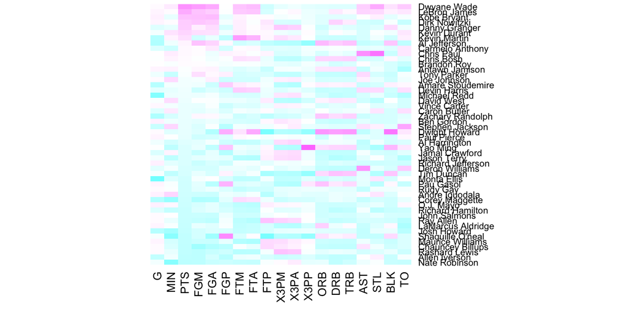

```r
nba_heatmap <- heatmap(nba_matrix,
                       Rowv=NA, Colv=NA,
                       col = cm.colors(256), scale="column")
```

## Opportunity

- Our data for a publication
- Alsagaby SA, et al J Proteome Res. 2014 13:5051-62 [doi: 10.1021/pr5002803](http://pubs.acs.org/doi/abs/10.1021/pr5002803)

## Opportunity

My first cluster dendrogram

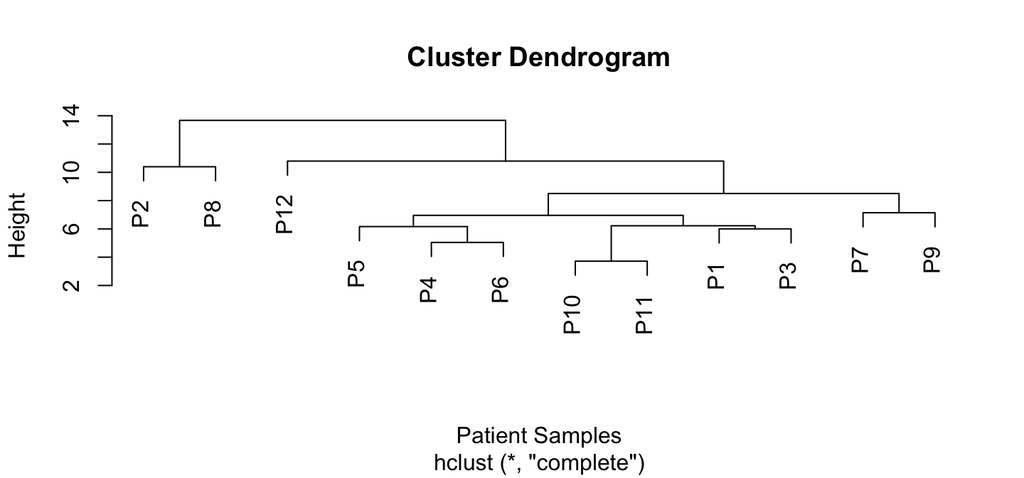

```r
# make the cluster dendrogram object using the hclust() and dist() functions
hc <- hclust(dist(rbind(P1, P2, P3, P4, P5, P6, P7, P8, P9, P10, P11, P12)))

# plot the cluster dendrogram
plot(hc, xlab = "Patient Samples")
```

## Willingness to learn and share

- My professional society - [the Biochemical Society](https://www.biochemistry.org/).
- Suggested a training day in R
- Then, I was organising it and delivering it
- Created a blog: R for Biochemists
- Delivered a training day - June 2015
- Further training in Cardiff, Germany and [Namibia](http://www.cardiff.ac.uk/phoenix-project)

## Open Source Learning & Teaching

- [R for Biochemists Blog](http://rforbiochemists.blogspot.co.uk)

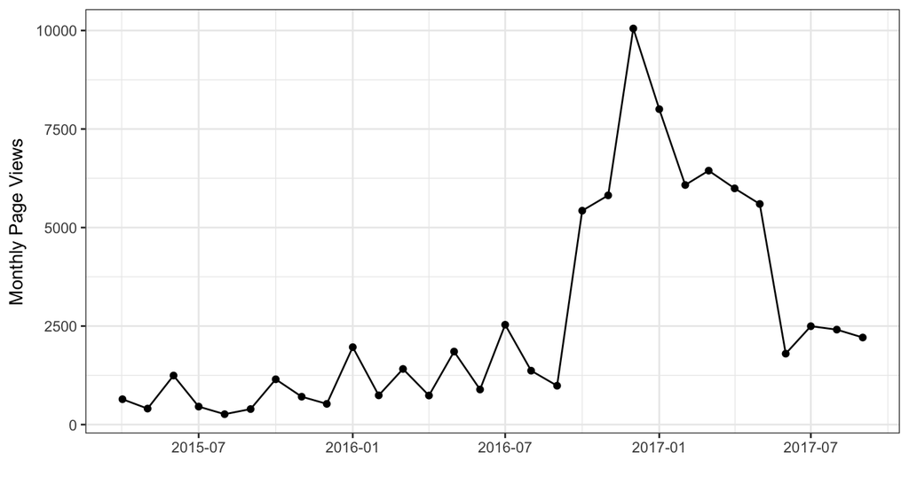

## Open Source Learning & Teaching

- [R User Group](http://www.meetup.com/Cardiff-R-User-Group/)
- Making packages - talk on 2nd of November
- twitter: @brennanpcardiff #rstats

## Package development

- A package is a collection of R functions
- Created and shared with the community
- Packages are being developed regularly
- Hosted on github, CRAN, Bioconductor

## drawProteins Package

- Bringing together webscraping and data visualisation
- Our bodies are made up of cells
- These cells depend on molecules called proteins
- Built a package to generate visualistions of these proteins

## drawProteins Package - learning continues

- Testing functions
- Package coverage
- Documentation

## drawProteins Package - demo

Keratin - an important skin and hair protein

```
## [1] "Download has worked"
```

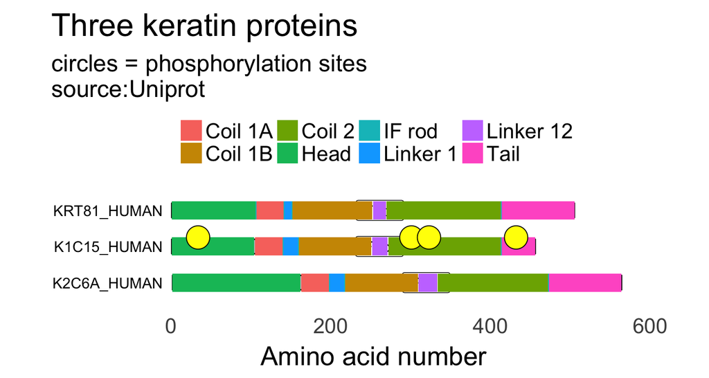

## Summary - becoming a better data analyst

- TIME and PATIENCE
- Inspiration
- Reasons to stay committed
- Open Source Learning & Teaching

## Acknowledgements

- Thanks for the invitation
- [Cardiff University](http://www.cardiff.ac.uk/) pays my salary
- [Biochemical Society](https://www.biochemistry.org/default.aspx) for support & advertising for the R for Biochemists Training day
- Biochemcial Society - online training
- CaRdiff R-Users Group - [Stef Locke](https://itsalocke.com/) and [Dave Parr](https://github.com/DaveRGP)
- This presentation made in [Rmarkdown using R-Studio](http://rmarkdown.rstudio.com/)